# Part II - Ford GoBike System Data Analysis

## by (Yonathan Lesanework Ferede)

## Investigation Overview

In this investigation, I wanted to look at an in depth analysis of the demographic characteristics of the users of bikeshare system. I also wanted to shed light on what the frequently used stations are and whether we can predict where a customer will go by the starting station. We'll also look at whether the age of the users influences the duration of trips taken by the customers.

## Dataset Overview

The data consisted of around 180,000 customers' demographic characteristics as well as duration, information about start and stopping stations. Location (latitude & longitude) data was combined to create further understanding in the analysis.

### 1.Lets see the Demographic distribution of the users by investigating the gender and age data.

From the bar chart, we can clearly observe that Male customers are the most frequent users of the bike sharing service with more than 3x as much as Female customers.

#### A. Gender

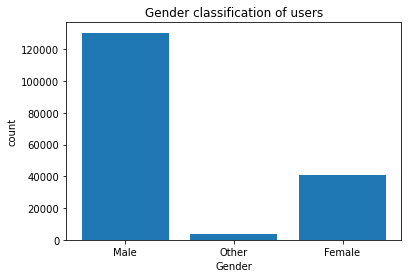

#### B. Age

People born from the year 1988 - 1992 are the frequent users of the service.

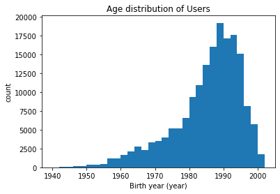

### 2. What are the stations where users pick up and drop off the bikes the most?

Market St. at 10 St and San Francisco Caltrain Station 2 (Townsend ST at 4th st) are the most frequent starting and ending stations respectively.

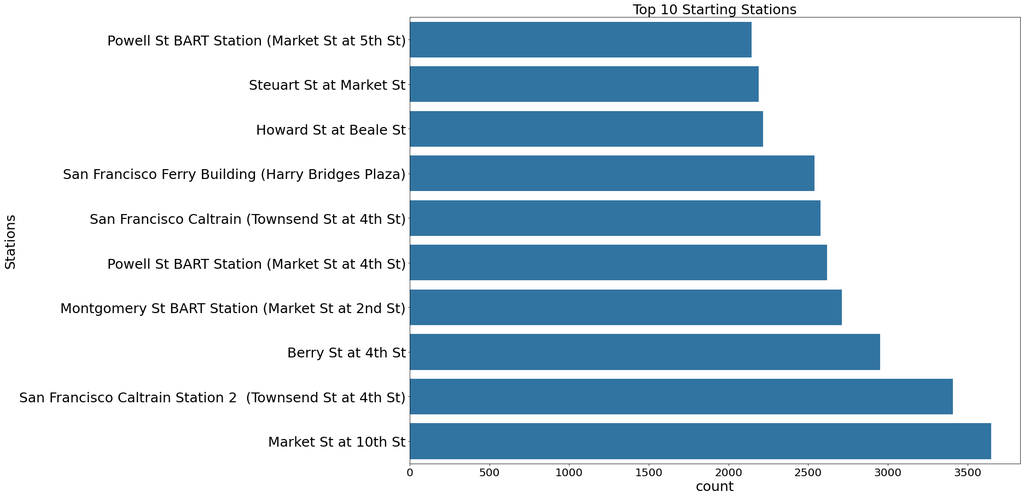

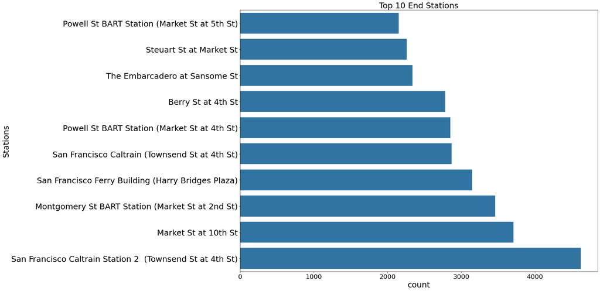

### What does the distribution of the Age of the customers look like across all genders?

From our Violin and box plots, we can observe that the mean age has only slight difference between all genders. We can also observe a slightly more concentrated age profile for Female customers.

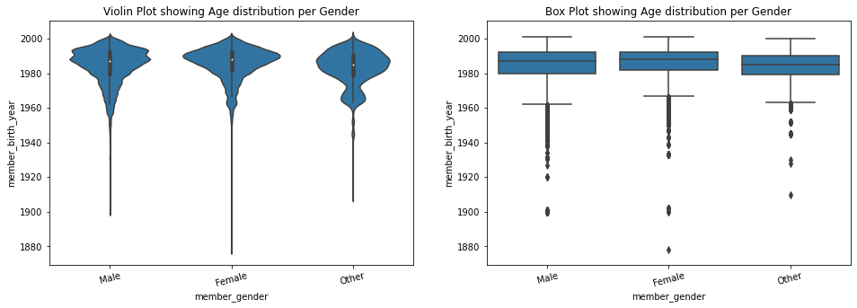

### Do younger people ride the bikes for longer durations?

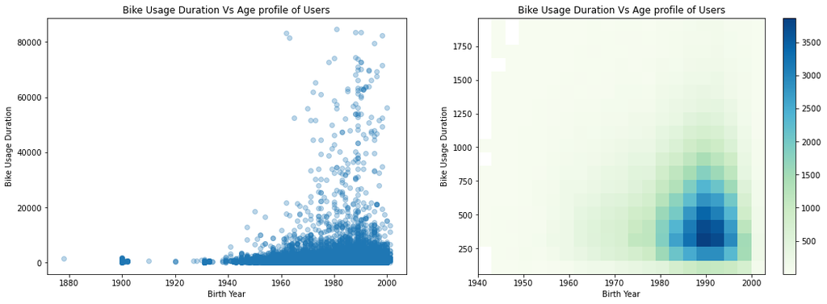

### What does a correlation matrix show us about the relationship of the variables?

From our visualization, we can observe a slight positive correlation between the displacement and duration. We can also observe a correlation between Start station Id and end station Id meaning we might be able to where a customer will go from their start station.

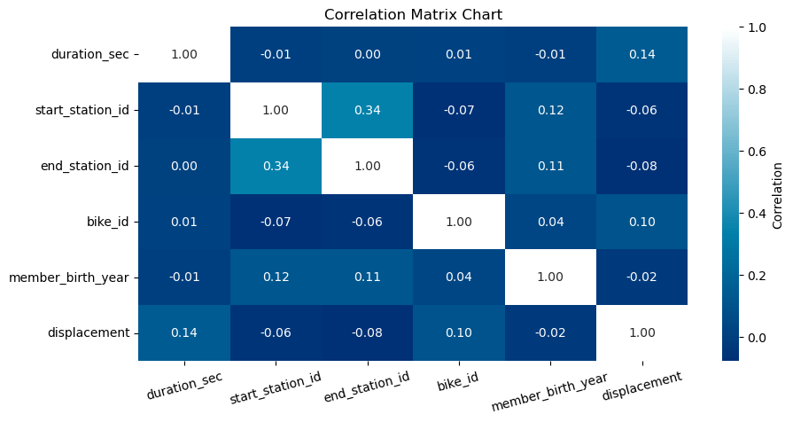